# Scrub Oak GLMM all groups

# All graphing can be found at the end of the script/document

# Other hidden analysis: early data visualization:

# Scrub Oak Large Seedling GLMM Code:

This code uses all the same steps to import large seedling data before refining it to Scrub Oak (QUIL, QUPR). These are the same steps as in the PIRI script and are hidden below in one chunk

Source large seedling data:

```r
source("Scripts/LS_Import.R")
```

Filter just for shrub oaks:

```r
ls_SO <- ls_merge %>%
  filter(Species_Groups == "Shrub Oak") %>%
  arrange(Treat_Type)

# make explanatory variables factors -------------------
ls_SO$Treat_Type = factor(ls_SO$Treat_Type,
                            levels = unique(ls_SO$Treat_Type))
ls_SO$Region = factor(ls_SO$Region,
                        levels = unique(ls_SO$Region))
ls_SO$Site = factor(ls_SO$Site,
                      levels = unique(ls_SO$Site))
```

Import time since data and add it to the Shrub Oak dataset

```r
time_since <- read_csv("CleanData/Treat_Year_Data.csv")
ls_SO2 <- merge(ls_SO, time_since, by = 'Site')
#log transform time from treatment data
ls_SO2$l.TFT <- log(ls_SO2$Time_from_Treat)
```

Run the ‘Add_BA’ script and merge with dataset:

```r
source("Scripts/Add_BA.R")
```

```r
# merge with ls dataset -------------------
ls_SO3 <- merge(ls_SO2, prism_BA, by = "Plot_No")
```

Run ‘Ground_Data.R’ script and add it to dataset:

```r
source("Scripts/Ground_Data.R")

# merge with ls dataset -------------------
ls_SO.all <- merge(ls_SO3, ground3, byt = "Plot_No")

rm(ls_SO3,
   ls_SO2)
```

Hidden below are early models that used the poisson distribution. All are underdispersed:

Unable to find a working model at this point.

This is the best model, but it is still underdispersed

ls_gp6 <- glmmTMB(Total~Treat_Type + l.BA_HA + (1|Site/Plot_No) + offset(l.TFT), data = ls_SO.all, family = genpois) AIC(ls_gp6)

ls.gp6_sr <- simulateResiduals(ls_gp6, n=1000, plot = TRUE)

testDispersion(ls.gp6_sr, alternative = ‘less’) #fails testZeroInflation(ls.gp6_sr) #passes testOutliers(ls.gp6_sr) #passes

I tried just a lmm, but it was very not normal/bad model and also I wasn’t able to use plot as a random variable within site

Giving up for now. Need to circle back

#Other hidden analysis: early data visualization:

Sapling data set up

Source sapling data:

```r
source("Scripts/SA_Import.R")
```

# Scrub Oak Sapling GLMM Code:

This code uses all the same steps to import large seedling data before refining it to Scrub Oak (QUIL, QUPR). These are the same steps as in the PIRI script and are hidden below in one chunk

Filtering just for Shrub Oaks:

```r
sapling_SO <- sapling_merge %>%
  filter(Species_Groups == "Shrub Oak") %>%
  arrange(Treat_Type)
```

Import time since data and add it to the dataset

```r
time_since <- read_csv("CleanData/Treat_Year_Data.csv")
sapling_SO2 <- merge(sapling_SO, time_since, by = 'Site')
#log transform time from treatment data
sapling_SO2$l.TFT <- log(sapling_SO2$Time_from_Treat)
```

Run the ‘Add_BA’ script and merge with dataset:

```r
source("Scripts/Add_BA.R")
```

```r
# merge with ls dataset -------------------
sapling_SO3 <- merge(sapling_SO2, prism_BA, by = 'Plot_No')
```

Run ‘Ground_Data.R’ script and add it to the dataset:

```r
source("Scripts/Ground_Data.R")

# merge with ls dataset -------------------
sa.so_alldata <- merge(sapling_SO3, ground3, by = 'Plot_No')

rm(sapling_SO3,
   sapling_SO2)

#there are 44 scrub oak sapling observations out of 487 sites
```

Models tested for shrub oak sapling data:

```r
sa.so_all <- glmmTMB(Total_Tally ~ Treat_Type + l.BA_HA + avgLD_l + (1|Site/Plot_No) + offset(l.TFT),
                     data = sa.so_alldata,
                     family = poisson)
AIC(sa.so_all) #309
```

```
## [1] 309.0458
```

```r
# best model -------------------
sa.so_p2 <- glmmTMB(Total_Tally ~ Treat_Type + l.BA_HA + (1|Site/Plot_No) + offset(l.TFT),
                     data = sa.so_alldata,
                     family = poisson)
AIC(sa.so_p2) #307.8, passes DHARMa test
```

```
## [1] 307.7773
```

```r
lrtest(sa.so_all, sa.so_p2) # p = .4
```

```
## Likelihood ratio test
##
## Model 1: Total_Tally ~ Treat_Type + l.BA_HA + avgLD_l + (1 | Site/Plot_No) +
##     offset(l.TFT)
## Model 2: Total_Tally ~ Treat_Type + l.BA_HA + (1 | Site/Plot_No) + offset(l.TFT)
##   #Df  LogLik Df  Chisq Pr(>Chisq)
## 1   9 -145.52
## 2   8 -145.89 -1 0.7314     0.3924
```

```r
sa.so_p1 <- glmmTMB(Total_Tally ~ Treat_Type + (1|Site/Plot_No) + offset(l.TFT),
                    data = sa.so_alldata,
                    family = poisson)
AIC(sa.so_p1) #305.9, doesn't pass DHARMa test
```

```
## [1] 305.9226
```

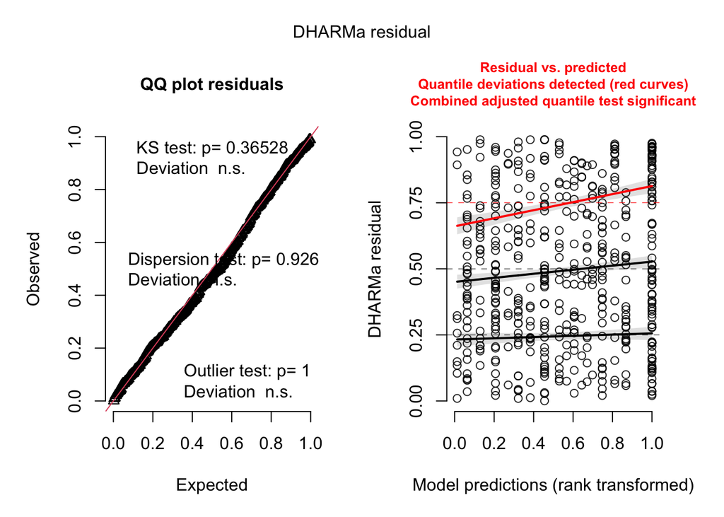

```r
sa.so1_sr <- simulateResiduals(sa.so_p1, n=1000, plot = T)
```

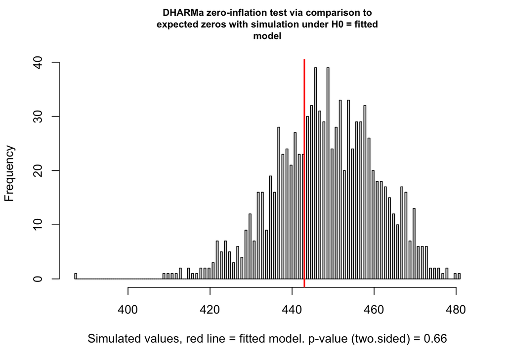

```
##
##  DHARMa zero-inflation test via comparison to expected zeros with
##  simulation under H0 = fitted model
##
## data:  simulationOutput
## ratioObsSim = 0.98771, p-value = 0.66
## alternative hypothesis: two.sided
```

```r
testZeroInflation(sa.so1_sr) #passes, guess we don't need to use a zero inflated model; but model needs work
```

```r
sa.so_p4 <- glmmTMB(Total_Tally ~ Treat_Type + (1|Site/Plot_No),
                    data = sa.so_alldata,
                    family = poisson)
AIC(sa.so_p4) #doesn't pass dharma test
```

```
## [1] 307.0425
```

```r
lrtest(sa.so_p1, sa.so_p4) #offset is valuable
```

```
## Likelihood ratio test
##
## Model 1: Total_Tally ~ Treat_Type + (1 | Site/Plot_No) + offset(l.TFT)
## Model 2: Total_Tally ~ Treat_Type + (1 | Site/Plot_No)
##   #Df  LogLik Df  Chisq            Pr(>Chisq)
## 1   7 -145.96
## 2   7 -146.52  0 1.1199 < 0.00000000000000022 ***
## ---
## Signif. codes:  0 '***' 0.001 '**' 0.01 '*' 0.05 '.' 0.1 ' ' 1
```

```r
rm(sa.so_all,
   sa.so_p4)
```

Run DHARMa package to check residuals:

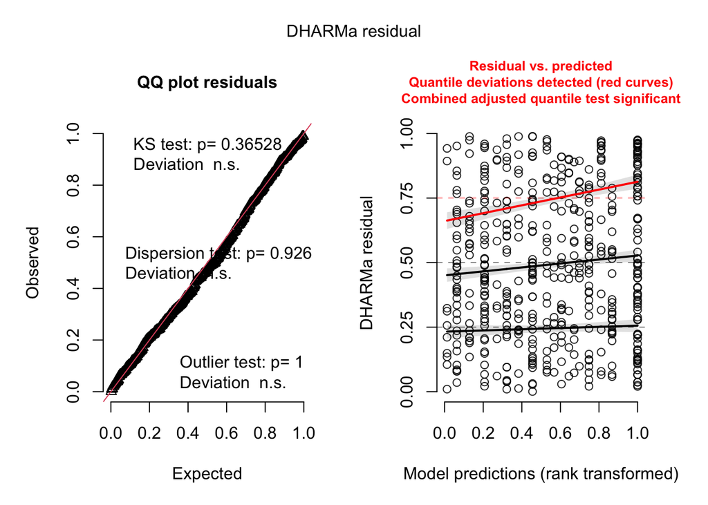

```r
sa.so1_sr <- simulateResiduals(sa.so_p1, n=1000, plot = T) #combined adjusted quantile test is significant
```

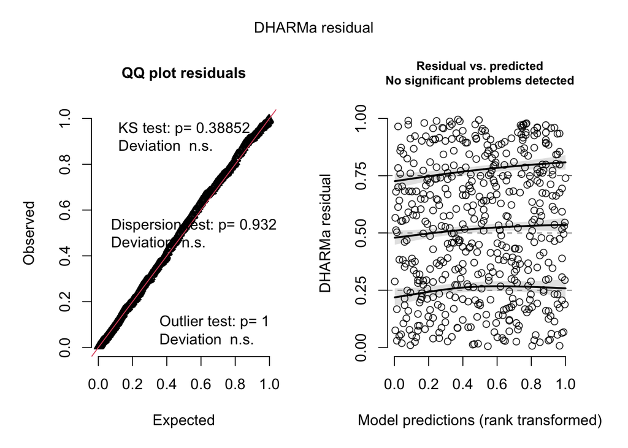

```r
sa.so2_sr <- simulateResiduals(sa.so_p2, n=1000, plot = T) #combined adjusted quantile test is non-significant
```

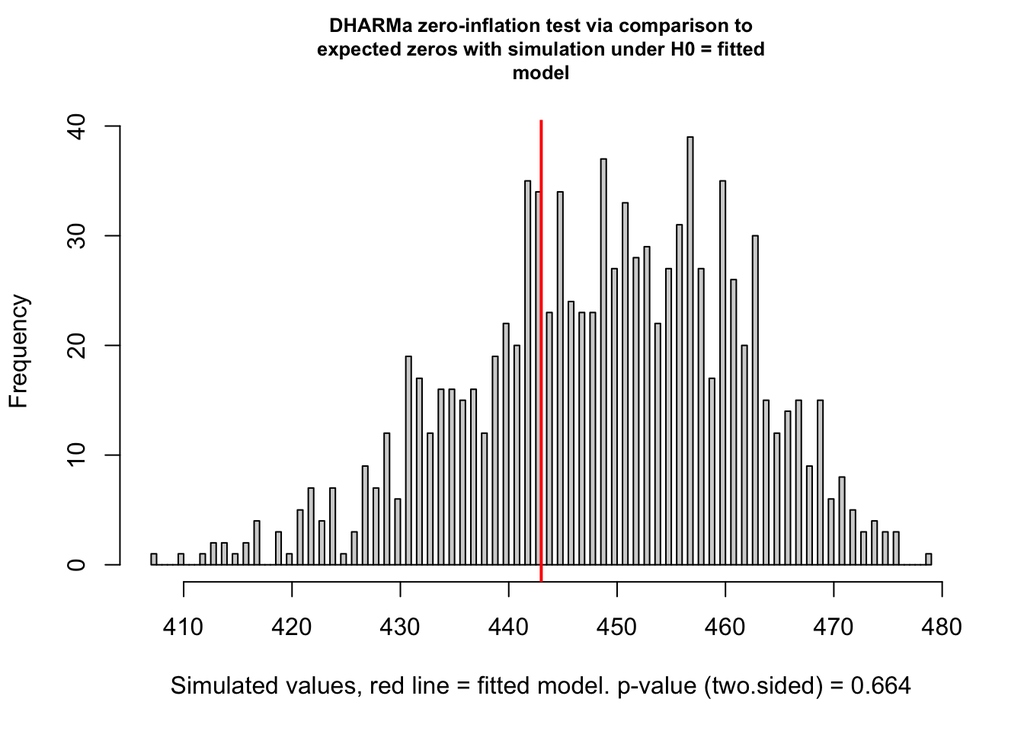

```
##
##  DHARMa zero-inflation test via comparison to expected zeros with
##  simulation under H0 = fitted model
##
## data:  simulationOutput
## ratioObsSim = 0.98695, p-value = 0.664
## alternative hypothesis: two.sided
```

```r
testZeroInflation(sa.so2_sr) #passes
```